# PML Course Project

DePoint

Sunday, June 14, 2015

## Intro

Using devices such as Jawbone Up, Nike FuelBand, and Fitbit it is now possible to collect a large amount of data about personal activity relatively inexpensively. These type of devices are part of the quantified self movement - a group of enthusiasts who take measurements about themselves regularly to improve their health, to find patterns in their behavior, or because they are tech geeks. One thing that people regularly do is quantify how much of a particular activity they do, but they rarely quantify how well they do it.

In this project, your goal will be to use data from accelerometers on the belt, forearm, arm, and dumbell of 6 participants. They were asked to perform barbell lifts correctly and incorrectly in 5 different ways. These are captured in the (outcome) variable called “classe”

## Setup the Environment

```r
library(caret);library(rattle);library(dplyr)
```

## get the data and bring it into memory only

```r
trainUrl <-"http://d396qusza40orc.cloudfront.net/predmachlearn/pml-training.csv"
testUrl <- "http://d396qusza40orc.cloudfront.net/predmachlearn/pml-testing.csv"
training <- read.csv(url(trainUrl))
testing <- read.csv(url(testUrl))
```

## clean the data

lets examine missing values, near zero variables, redundant variables, etc

```r
nsv <- nearZeroVar(training,saveMetrics=TRUE)
nsvDropList <- names(training) %in% as.list(row.names(subset(nsv, nzv=='TRUE',select=nzv)))
slimTraining <- training[!nsvDropList]
#crunch through again to remove all missing
slimTraining <- slimTraining[, colSums(is.na(slimTraining)) == 0]
```

After cycling through some modeling, these variables cause some issues. lets remove

```r
slimTraining <- slimTraining[, !grepl("^X", names(slimTraining))]
#slimTraining <- select(slimTraining,
#                 -c(raw_timestamp_part_1,raw_timestamp_part_2,cvtd_timestamp))
dim(slimTraining);str(slimTraining)
```

```
## [1] 19622    58
```

```
## 'data.frame':    19622 obs. of  58 variables:
##  $ user_name           : Factor w/ 6 levels "adelmo","carlitos",..: 2 2 2 2 2 2 2 2 2 2 ...
##  $ raw_timestamp_part_1: int  1323084231 1323084231 1323084231 1323084232 1323084232 1323084232 1323084232 1323084232 1323084232 1323084232 ...
##  $ raw_timestamp_part_2: int  788290 808298 820366 120339 196328 304277 368296 440390 484323 484434 ...
##  $ cvtd_timestamp      : Factor w/ 20 levels "02/12/2011 13:32",..: 9 9 9 9 9 9 9 9 9 9 ...
##  $ num_window          : int  11 11 11 12 12 12 12 12 12 12 ...
##  $ roll_belt           : num  1.41 1.41 1.42 1.48 1.48 1.45 1.42 1.42 1.43 1.45 ...
##  $ pitch_belt          : num  8.07 8.07 8.07 8.05 8.07 8.06 8.09 8.13 8.16 8.17 ...
##  $ yaw_belt            : num  -94.4 -94.4 -94.4 -94.4 -94.4 -94.4 -94.4 -94.4 -94.4 -94.4 ...
##  $ total_accel_belt    : int  3 3 3 3 3 3 3 3 3 3 ...
##  $ gyros_belt_x        : num  0 0.02 0 0.02 0.02 0.02 0.02 0.02 0.02 0.03 ...
##  $ gyros_belt_y        : num  0 0 0 0 0.02 0 0 0 0 0 ...
##  $ gyros_belt_z        : num  -0.02 -0.02 -0.02 -0.03 -0.02 -0.02 -0.02 -0.02 -0.02 0 ...
##  $ accel_belt_x        : int  -21 -22 -20 -22 -21 -21 -22 -22 -20 -21 ...
##  $ accel_belt_y        : int  4 4 5 3 2 4 3 4 2 4 ...
```

[output cut: 44 more lines]

## Partition the data

Create a training and validation data set out of the Slim Training data set

```r
set.seed(8675309)
trainflag <- createDataPartition(slimTraining$classe, p=0.70, list=FALSE)
modelingData <- slimTraining[trainflag, ]
validationData <- slimTraining[-trainflag, ]
```

## Modeling the Data

we wish to predict the manner in which people exercise, using classe as the dependent variable

```r
fit1 <- train(classe ~ .,method="rpart",data=modelingData)
```

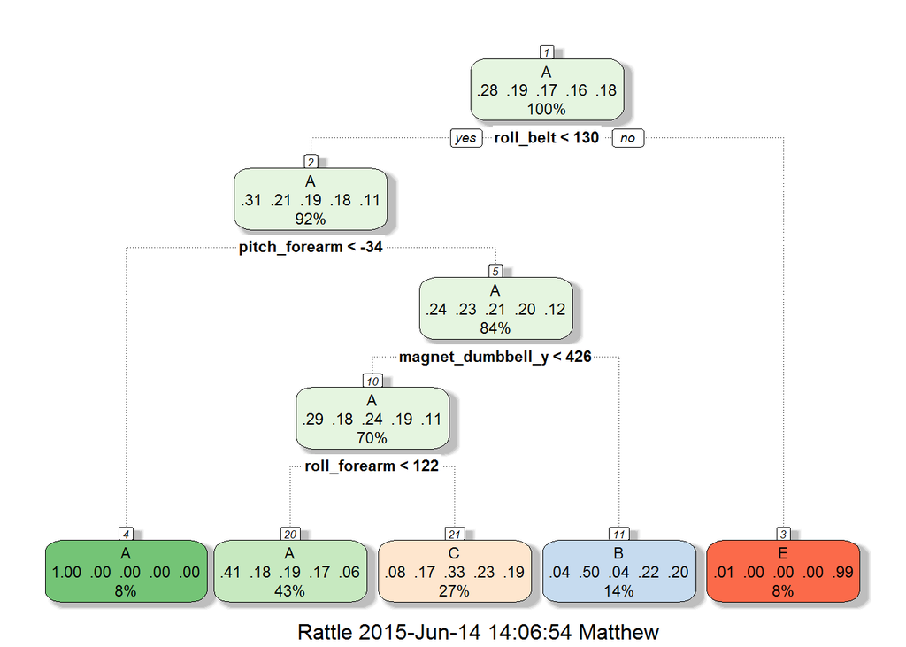

```r
rattle::fancyRpartPlot(fit1$finalModel)
```

```r
predFit1 <- predict(fit1, validationData)
confusionMatrix(validationData$classe, predFit1)
```

```
## Confusion Matrix and Statistics
##
##           Reference
## Prediction    A    B    C    D    E
##          A 1500   47  121    0    6
##          B  458  384  297    0    0
##          C  462   49  515    0    0
##          D  421  200  343    0    0
##          E  160  153  274    0  495
##
## Overall Statistics
##
##                Accuracy : 0.4918
##                  95% CI : (0.4789, 0.5046)
##     No Information Rate : 0.5099
##     P-Value [Acc > NIR] : 0.9975
##
##                   Kappa : 0.3365
##  Mcnemar's Test P-Value : NA
##
## Statistics by Class:
##
##                      Class: A Class: B Class: C Class: D Class: E
## Sensitivity            0.4998  0.46098  0.33226       NA  0.98802
## Specificity            0.9397  0.85055  0.88212   0.8362  0.89097
## Pos Pred Value         0.8961  0.33714  0.50195       NA  0.45749
## Neg Pred Value         0.6436  0.90539  0.78699       NA  0.99875
## Prevalence             0.5099  0.14155  0.26338   0.0000  0.08513
## Detection Rate         0.2549  0.06525  0.08751   0.0000  0.08411
## Detection Prevalence   0.2845  0.19354  0.17434   0.1638  0.18386
## Balanced Accuracy      0.7198  0.65577  0.60719       NA  0.93950
```

```r
#I had to really mess with this RF to make it work on my $500 computer. frown
fit2 <- train(classe ~ ., data=modelingData, method="rf", trControl=trainControl(method="cv", 5), ntree=250)
predFit2 <- predict(fit2, validationData)
confusionMatrix(validationData$classe, predFit2)
```

```
## Confusion Matrix and Statistics
##
##           Reference
## Prediction    A    B    C    D    E
##          A 1674    0    0    0    0
##          B    0 1139    0    0    0
##          C    0    0 1025    1    0
##          D    0    0    2  961    1
##          E    0    0    0    0 1082
##
## Overall Statistics
##
##                Accuracy : 0.9993
##                  95% CI : (0.9983, 0.9998)
##     No Information Rate : 0.2845
##     P-Value [Acc > NIR] : < 2.2e-16
##
##                   Kappa : 0.9991
##  Mcnemar's Test P-Value : NA
##
## Statistics by Class:
##
##                      Class: A Class: B Class: C Class: D Class: E
## Sensitivity            1.0000   1.0000   0.9981   0.9990   0.9991
## Specificity            1.0000   1.0000   0.9998   0.9994   1.0000
## Pos Pred Value         1.0000   1.0000   0.9990   0.9969   1.0000
## Neg Pred Value         1.0000   1.0000   0.9996   0.9998   0.9998
## Prevalence             0.2845   0.1935   0.1745   0.1635   0.1840
## Detection Rate         0.2845   0.1935   0.1742   0.1633   0.1839
## Detection Prevalence   0.2845   0.1935   0.1743   0.1638   0.1839
## Balanced Accuracy      1.0000   1.0000   0.9989   0.9992   0.9995
```

the accuracy on the fit2 model, a randomforest, was much higher at 0.99. lets choose that one. Create predictions based upon the testing data of 20 observations

```r
scoreTest <- predict(fit2, testing)
scoreTest
```

```
##  [1] B A B A A E D B A A B C B A E E A B B B
## Levels: A B C D E
```